# Lyft Bay Wheel's trip dataset exploration

### Did you observe any interesting relationships between the other features (not the main feature(s) of interest)? 🔔

> There aren't a lot of variables that is not the main feature of interest. It is `user_type`, `bike_share_for_all_trip`, `rental_access_method`, `rideable_type`, and `is_equity`. We could spend more time on these but seems the data is not complete at all except `user_type` and didn't planed to expand to this **service details** I only compared one relationship!

**`user type` vs `bike share for all trip`**

- These `2 variables` are **the most filled ones** among the `5 variables`!

`Bike share for all trip` is a annual plan for **Bay Area residents**. So its not surprising that people who is just a `customer`(who is not a subscriber) doesn't have `bike share for all trip` plan. And even for subscriber only `9.86%` are using the `bike share for all trip` plan. Considering the benefits it's not high. There could be reason why people don't subscribe to this wonderful plan. Maybe they didn't need that much ride or just decided to ride a car rather bike. If we could gather more data maybe we could answer this.

**Further exploration could be done between `5 service details variable` vs `time`, `location`, `bike`. I'm not going to do here but will be left for someday.**

## Multivariate Exploration ✅

**bivariate visualization**

- Non-Positional Encodings
  - **Shape** `qualitative variables`
  - **Size** `quantitative variables`
  - **color** `quantitative variables` & `qualitative variables`
- Faceting
- Adaption of bivariate plots
  - `Point plots`
  - `Violin plots`
  - `Box plots`
  - `hist 2d`
  - `bar plot`
- Plot Matrices

**explore**

- `Correlation` between variables
- `Top50` bike trip route visualization on map
- Average ride time for top10 `bike` & top10 `location`
- `Distance & bike usage time` of user's bike travel **per start hour**

### Correlation between variables

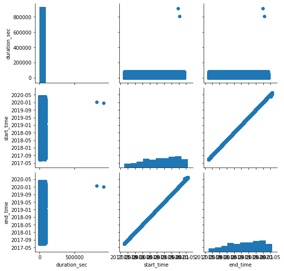

```python
g = sb.PairGrid(data=df, vars=['duration_sec',
                               'start_time',
                               'end_time'])
g.map_diag(plt.hist)
g.map_offdiag(plt.scatter)
```

📝 **comment** 🔔 🔎

Other variables won't have correlation between them. Let's finish the formal analysis and move on!

### Top50 bike trip route visualization on map

```python
# make a new copy of original to add new column "hour"
bike_df = df.copy()

# leave the necessary columns
bike_df = bike_df[['duration_sec', 'start_station_name', 'end_station_name']]

# Remove NaN values
bike_df = bike_df[~(bike_df.start_station_name.isna() |
                    bike_df.end_station_name.isna())]

# Check values
bike_df.sample(5)
```

|  | duration_sec | start_station_name | end_station_name |
| --- | --- | --- | --- |
| 2054646 | 1062 | MacArthur BART Station | 13th St at Franklin St |
| 4591699 | 774 | 3rd St at Townsend St | Esprit Park |
| 1886949 | 1196 | 4th St at Mission Bay Blvd S | San Francisco City Hall (Polk St at Grove St) |
| 4724494 | 611 | San Francisco Caltrain (Townsend St at 4th St) | Salesforce Transit Center (Natoma St at 2nd St) |
| 4727558 | 345 | Octavia Blvd at Page St | S Van Ness Ave at Market St |

```python
route = bike_df.groupby(['start_station_name', 'end_station_name']).count().reset_index()
route.rename(columns={'duration_sec': 'count'}, inplace=True)
```

```python
# sort by count
route = route.sort_values(by='count', ascending=False)
```

```python
from_list = route.iloc[:50].start_station_name.values
to_list = route.iloc[:50].end_station_name.values
```

```python
from_xys = []
to_xys = []

# Get longitude and latitude for each from and to list
for i in range(len(from_list)):
    # start station (from)
    lng, lat = df.query('start_station_name == "{}"'.format(from_list[i])) \
               [['start_station_longitude', 'start_station_latitude']].iloc[i].values
    from_xys.append([lng, lat])

    # end station (to)
    lng, lat = df.query('end_station_name == "{}"'.format(to_list[i])) \
               [['end_station_longitude', 'end_station_latitude']].iloc[i].values
    to_xys.append([lng, lat])
```

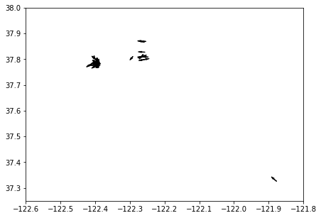

```python
plt.figure(figsize=[7, 5])
ax = plt.axes()

for from_xy, to_xy in zip(from_xys, to_xys):
    ax.arrow(from_xy[0], # x
             from_xy[1], # y
             to_xy[0] - from_xy[0], # dx
             to_xy[1] - from_xy[1], # dy
             head_width=0.005,
             head_length=0.01,
             facecolor='black',
             edgecolor='black')

plt.xlim([-122.6, -121.8])
plt.ylim([37.25, 38]);
```

You can see the `3 area` that has bike movement! and **looks like we need to increase the scale to see more clearly!**

We will look closely at `San Francisco` and `East Bay` area!

**Caveat**

- Different from upper maps this time the `longitude`, `latitude` is not matched precisely
- This will show where the lyft bike usage is mostly coming from approximately
- The image was from https://member.baywheels.com/map/ screenshot

[figure not shown]

```python
plt.figure(figsize=[12, 12])
ax = plt.axes()

for from_xy, to_xy in zip(from_xys, to_xys):
    ax.arrow(from_xy[0], # x
             from_xy[1], # y
             to_xy[0] - from_xy[0], # dx
             to_xy[1] - from_xy[1], # dy
             head_width=0.005,
             head_length=0.01,
             facecolor='blue',
             edgecolor='red')

image = plt.imread('lyft_bike_station.png', format='png')
ax.imshow(image, extent=[-122.58, -122.18, 37.62, 37.95])

plt.title("Top50 lyft bike route", fontsize=20)
plt.xlabel('Longitude', fontsize=16)
plt.ylabel('Latitude', fontsize=16)

plt.xlim([-122.5, -122.18])
plt.ylim([37.65, 37.95]);
```

📝 **comment** 🔔 🔎

To show the bike route visually we need `coordinate information`. By mapping the `station name` to `longitude` and `latitude` information we could draw an arrow showing user moving where to where. This is **4 numeric variables** so I used `arrow` to **express the route**!

- `Top50 route` is focused on the **San Francisco near bay**
- **East bay** have approximately **9 route** for `Top50`
- **San Jose** has only **1 route** that get inside `Top50`

Map `longitude` and `latitude` is not precisely match so we might not be sure about the route shown on the map but we could get glimpse of where the user mostly use the bike!

- **San Francisco near bay** is place for travel. Maybe most users are using the bike not for commuting rather traveling.

[figure not shown]

### Average ride time for top10 bike & top10 location

```python
# make a new copy of original
bike_df = df.copy()

# leave the necessary columns
bike_df = bike_df[['bike_id', 'start_station_name', 'end_station_name', 'duration_sec']]

# Remove NaN values
bike_df = bike_df[~(bike_df.bike_id.isna() |
                    bike_df.start_station_name.isna() |
                    bike_df.end_station_name.isna() |
                    bike_df.duration_sec.isna())]

# Check values
bike_df.sample(5)
```

|  | bike_id | start_station_name | end_station_name | duration_sec |
| --- | --- | --- | --- | --- |
| 5212257 | 11379 | Mission Playground | Valencia St at 16th St | 188 |
| 3837763 | 219079 | Market St at 10th St | San Francisco Caltrain Station 2 (Townsend St... | 666 |
| 3034675 | 3441 | O'Farrell St at Divisadero St | McAllister St at Baker St | 3347 |
| 2693505 | 5280 | Powell St BART Station (Market St at 5th St) | Alamo Square (Steiner St at Fulton St) | 699 |
| 4813085 | 9803 | Raymond Kimbell Playground | O'Farrell St at Divisadero St | 206 |

```python
# Leave the information of the top10 bikes
top10_bike = list(bike_df.bike_id.value_counts().iloc[:10].index)
bike_10 = bike_df.query('bike_id in @top10_bike')

# Melt to merge the two start and end station
bike_10 = pd.melt(bike_10, id_vars=['bike_id', 'duration_sec'], var_name='station', value_name='location')

# Leave the information of the top10 locations
top10_station = list(bike_10.location.value_counts().iloc[:10].index)
top10 = bike_10.query('location in @top10_station').copy()

# Drop the station column
top10.drop(columns=['station'], inplace=True)
```

```python
# Make a rank index for sort!
bike_index = dict(zip(top10_bike, range(len(top10_bike))))
location_index = dict(zip(top10_station, range(len(top10_station))))

# Add a rank column for bike and location
top10['bike_rank'] = top10.bike_id.map(bike_index)
top10['location_rank'] = top10.location.map(location_index)

# Sort the value
top10.sort_values(['bike_rank', 'location_rank'], inplace=True)

# drop the rank column
top10.drop(columns=['bike_rank', 'location_rank'], inplace=True)

# Change bike_id int to object
top10.bike_id = top10.bike_id.astype('object')

# change duration_sec to minute to see more easy for human being QUARK
top10.duration_sec = top10.duration_sec/60

# rename second to minute
top10.rename(columns={'duration_sec': 'minute'}, inplace=True)
```

```python
top10
```

|  | bike_id | minute | location |
| --- | --- | --- | --- |
| 961 | 2174 | 5.933333 | San Francisco Ferry Building (Harry Bridges Pl... |
| 1172 | 2174 | 10.566667 | San Francisco Ferry Building (Harry Bridges Pl... |
| 2293 | 2174 | 4.816667 | San Francisco Ferry Building (Harry Bridges Pl... |
| 2616 | 2174 | 25.900000 | San Francisco Ferry Building (Harry Bridges Pl... |
| 2666 | 2174 | 7.600000 | San Francisco Ferry Building (Harry Bridges Pl... |
| ... | ... | ... | ... |
| 34949 | 126 | 16.766667 | Howard St at Beale St |
| 35344 | 126 | 11.016667 | Howard St at Beale St |
| 35853 | 126 | 5.850000 | Howard St at Beale St |
| 37057 | 126 | 4.933333 | Howard St at Beale St |
| 37699 | 126 | 23.816667 | Howard St at Beale St |

9687 rows × 3 columns

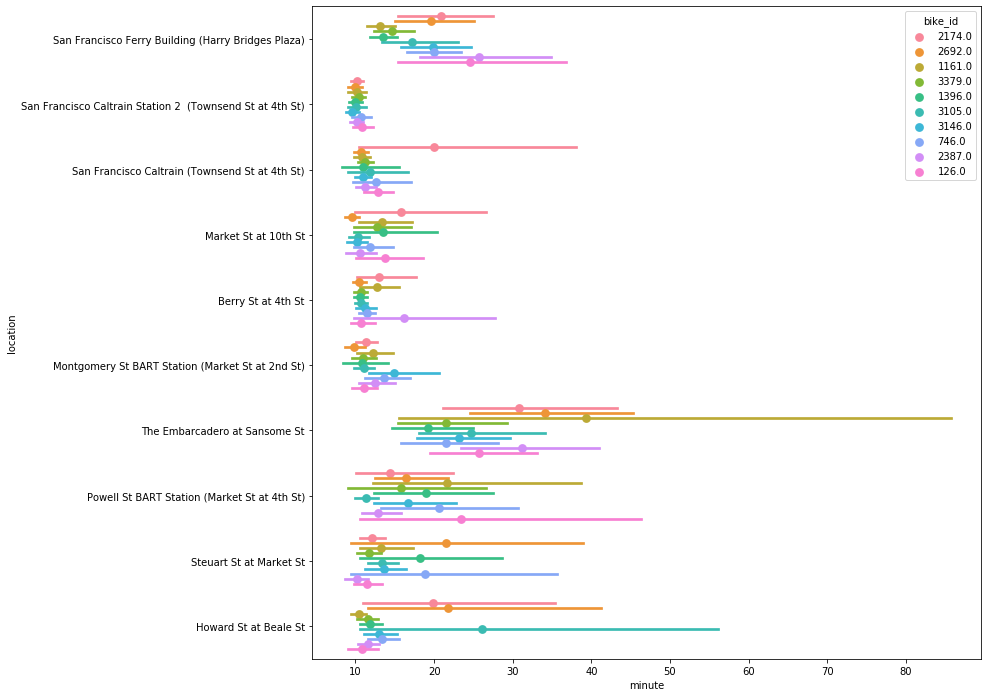

```python
# top10
plt.figure(figsize=[12, 12])
sb.set_palette('rocket')
sb.pointplot(data=top10, x='minute', y='location', hue='bike_id', hue_order=top10_bike,
             dodge=0.7, linestyles="");
```

📝 **comment** 🔔 🔎

I used `pointplot` to express the 3 variable relationship. And the `bike_id` is `qualitative` I used **rocket** color palette. This is showing the relationship between the `bike`, `location`, and `bike usage time`! When we compare the `bike` and `location` we could see that the `San Francisco Ferry Building (Harry Bridges Plaza)` has the most usage with bike **2692**. But **how long did the user used the bike**? We combined `duration_sec` and could get the answer.

- `San Francisco Ferry Building (Harry Bridges Plaza)` bike riders ride around **10-40 minutes**
- `The Embarcadero at Sansome St` bike **1161** has a record that run more than **80 minutes**
- Average bike usage time is all below **40 minutes**

When we consider most of the user ride bike for **6 minutes** and the bike usage distribution was at the edge around **1 hour** we could know that the `location` and `bike` is not the one belongs to the group of **6 minutes** ride ones that is mostly dominating the usage time. It means the most usage time **6 minutes** is not coming from the `top10` **bike** and **location**, its coming from other.

Besides your trying to ride a bike for traveling around it's hard to say you need to ride bike for a long time. We could get curious. We saw how long they ride. So how about **how fast they ride** and **how long distance they ride?**

### Distance & bike usage time of user's bike travel per start hour

```python
# make a new copy of original
bike_df = df.copy()

# leave the necessary columns
bike_df = bike_df[['start_time',
                   'start_station_longitude',
                   'end_station_longitude',
                   'start_station_latitude',
                   'end_station_latitude',
                   'duration_sec']]

# Remove NaN values
bike_df = bike_df[~(bike_df.start_time.isna() |
                    bike_df.start_station_longitude.isna() |
                    bike_df.end_station_longitude.isna() |
                    bike_df.start_station_latitude.isna() |
                    bike_df.end_station_latitude.isna() |
                    bike_df.duration_sec.isna())]

# Remove the values which the destination is same as the start station
bike_df = bike_df.query('start_station_longitude != end_station_longitude or start_station_latitude != end_station_latitude')

# Check values
bike_df.sample(5)
```

|  | start_time | start_station_longitude | end_station_longitude | start_station_latitude | end_station_latitude | duration_sec |
| --- | --- | --- | --- | --- | --- | --- |
| 5367409 | 2020-02-17 17:12:49.000 | -122.424241 | -122.406986 | 37.761623 | 37.777762 | 860 |
| 677284 | 2018-02-11 21:31:24.808 | -122.421866 | -122.420091 | 37.765052 | 37.764765 | 66 |
| 1335505 | 2018-06-01 14:53:15.826 | -122.408445 | -122.404904 | 37.783899 | 37.786375 | 196 |
| 2459176 | 2019-01-22 21:02:37.718 | -122.393028 | -122.431946 | 37.772301 | 37.780450 | 1093 |
| 2352312 | 2018-12-07 16:06:20.612 | -121.889277 | -121.901782 | 37.336188 | 37.329732 | 551 |

```python
# Change the start_time to hour
bike_df.start_time = bike_df.start_time.dt.hour

# calculate the difference of longitude between start and end
# apply abs
# change it to mile 1 degree of longitude = 69.172 miles
bike_df.start_station_longitude = bike_df.start_station_longitude - bike_df.end_station_longitude
bike_df.start_station_longitude = bike_df.start_station_longitude.map(abs)
bike_df.start_station_longitude = bike_df.start_station_longitude*69.172

# calculate the difference of latitude between start and end
# apply abs
# change it to mile 1 degree of longitude = 69 miles
bike_df.start_station_latitude = bike_df.start_station_latitude - bike_df.end_station_latitude
bike_df.start_station_latitude = bike_df.start_station_latitude.map(abs)
bike_df.start_station_latitude = bike_df.start_station_latitude*69

# Change second to hour
bike_df.duration_sec = bike_df.duration_sec/3600

# rename columns
bike_df.rename(columns={'start_time': 'start_hour',
                        'start_station_longitude': 'mile_lng',
                        'start_station_latitude': 'mile_lat',
                        'duration_sec': 'duration_hour'},
               inplace=True)

# calculate the total distance as mile
# When we consider the complicated roads on the city
# I calculate the distance as manhattan distance
bike_df.mile_lng = bike_df.mile_lng + bike_df.mile_lat

# rename mile_lng
bike_df.rename(columns={'mile_lng': 'distance_mile'}, inplace=True)

# drop the unnecessary columns
bike_df.drop(columns=['end_station_longitude', 'end_station_latitude', 'mile_lat'], inplace=True)
bike_df
```

|  | start_hour | distance_mile | duration_hour |
| --- | --- | --- | --- |
| 0 | 16 | 0.874466 | 22.252778 |
| 1 | 15 | 3.068013 | 21.888889 |
| 3 | 17 | 0.716630 | 17.270000 |
| 4 | 14 | 0.563977 | 12.111944 |
| 10 | 23 | 0.768118 | 0.914444 |
| ... | ... | ... | ... |
| 5795384 | 10 | 0.002418 | 0.016944 |
| 5795385 | 17 | 0.003017 | 0.021667 |
| 5795386 | 13 | 0.005138 | 0.033889 |
| 5795387 | 13 | 0.003407 | 0.094444 |
| 5795388 | 16 | 0.056517 | 0.092500 |

5648313 rows × 3 columns

The dataset is too big so we cut some data that ride more than `1 hour`

```python
bike_less = bike_df.query('duration_hour < 1')
```

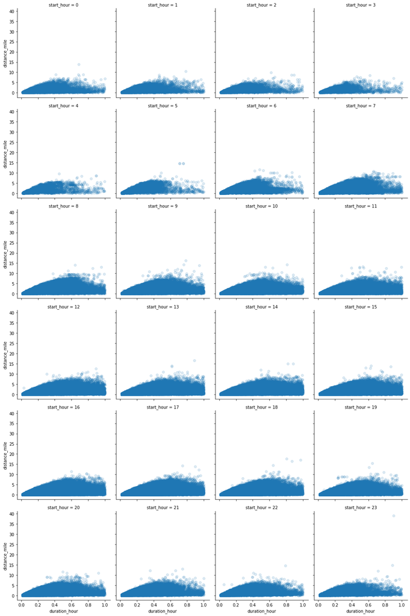

```python
g = sb.FacetGrid(data=bike_less, col='start_hour', col_wrap=4, height=3.5)
g.map(plt.scatter, 'duration_hour', 'distance_mile', alpha=0.15);
```

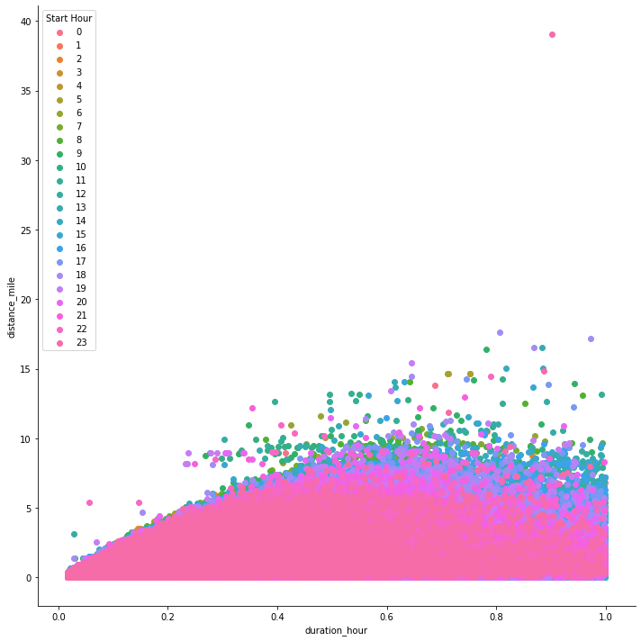

```python
g = sb.FacetGrid(data=bike_less, hue='start_hour', height=10)
g.map(plt.scatter, 'duration_hour', 'distance_mile')
plt.legend(title='Start Hour');
```

```python
# calculate velocity!
bike_df.distance_mile = bike_df.distance_mile/bike_df.duration_hour

# rename
bike_df.rename(columns={'distance_mile': 'mile_per_hour'}, inplace=True)
```

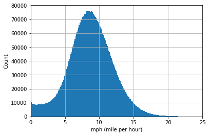

```python
interval = 0.1

bins = np.arange(0, 40 + interval, interval)
bike_df.mile_per_hour.hist(bins=bins)
plt.xlim(0, 25)
plt.xlabel('mph (mile per hour)')
plt.ylabel('Count');
```

Quite interesting that there are people who ride bike nearly `0 mph`.

```python
bike_df.mile_per_hour.value_counts()
```

```
14.568907    121
11.861108    114
16.294172    112
13.759523    109
9.066341     108
            ...
14.187723      1
3.383151       1
4.942265       1
7.848786       1
3.870374       1
Name: mile_per_hour, Length: 3331193, dtype: int64
```

📝 **comment** 🔔 🔎

All the variables are `numeric`. So I used **Faceting** and **scatterplot**. Due to data amount of size the scatter plot doesn't seem to show the clear relationship between `time` and `distance` but could check that distribution shows regardless of the **Start hour**!

**People who comeback to the place where they started to ride the bike is removed!**

- The speed of bike remains same till `24 minutes` and start to slow down as time go by. People are getting tired.
- Normally, people ride around `30 minutes` goes the furthest.
  - The `distance` user gone goes decreases after `30 minutes`
- There are outliers who ride the bike nearly **40 mph**
- Interestingly lots of people almost didn't moved from where they ride the regardless of bike using time.
  - Maybe they might ride and had to comeback but return to the nearby station they origianlly rental.

I looked at the **speed** more closely with **mph**.

### Talk about some of the relationships you observed in this part of the investigation. Were there features that strengthened each other in terms of looking at your feature(s) of interest? 🔔

> Looking at relationships with more variables strengthen a lot for analysis because we could look more in-depth compared to bivariate! We could start to look whatever we want to look at! We could trace the route at map, or look more steps from what we were looking at bivariate exploration! Before it was general exploration, from here we could dive into the details and reveal the real worlds truth!

**`Correlation` between variables**

**`longitude` vs `latitude`**

This use **4 numeric variables**. By this I could show the user's route visually at the map! So we could check where the user ride the bike.

- `Top50 route` is focused on the **San Francisco near bay**
- **East bay** have approximately **9 route** for `Top50`
- **San Jose** has only **1 route** that get inside `Top50`

Map `longitude` and `latitude` is not precisely match so we might not be sure about the route shown on the map but we could get glimpse of where the user mostly use the bike!

**`bike` vs `location` vs `bike usage time`**

This is showing the relationship between the `bike`, `location`, and `bike usage time`! When we compare the `bike` and `location` we could see that the `San Francisco Ferry Building (Harry Bridges Plaza)` has the most usage with bike **2692**. But **how long did the user used the bike**? We combined `duration_sec` and could get the answer.

- `San Francisco Ferry Building (Harry Bridges Plaza)` bike riders ride around **10-40 minutes**
- `The Embarcadero at Sansome St` bike **1161** has a record that run more than **80 minutes**
- Average bike usage time is all below **40 minutes**

When we consider most of the user ride bike for **6 minutes** and the bike usage distribution was at the edge around **1 hour** we could know that the `location` and `bike` is not the one belongs to the group of **6 minutes** ride ones that is mostly dominating the usage time. It means the most usage time **6 minutes** is not coming from the `top10` **bike** and **location**, its coming from other.

Besides your trying to ride a bike for traveling around it's hard to say you need to ride bike for a long time. We could get curious. We saw how long they ride. So how about **how fast they ride** and **how long distance they ride?**

**`start hour` vs `distance` vs `duration hour`**

**People who comeback to the place where they started to ride the bike is removed!**

- The speed of bike remains same till `24 minutes` and start to slow down as time go by. People are getting tired.
- Normally, people ride around `30 minutes` goes the furthest.
  - The `distance` user gone goes decreases after `30 minutes`
- There are outliers who ride the bike nearly **40 mph**
- Interestingly lots of people almost didn't moved from where they ride the regardless of bike using time.
  - Maybe they might ride and had to comeback but return to the nearby station they origianlly rental.

I looked at the **speed** more closely with **mph**.

### Were there any interesting or surprising interactions between features? 🔔

> Most of the results are predictable and reasonable. So hard to say there are surprising interactions! One thing that seems interesing was there are actually a lot of people who just ride the bike and nearly didn't move a lot!